# Fraud detection with ML Technique (SMOTE)

```
                                                                                                Hurgland-Nick KELIET
```

- La Détection de Fraud est un sujet majeur qui occupe une place très importante dans les missions des institutions financières tels que les banques et les instances de paiement en lignes. Ces institutions se sont centrés dans la detection de manoeuvres frauduleuses. Pour ce faire grace au Machine Learning nous allons découvrir comment créer un model de classification pour identifier ces transactions dites Frauduleuses, par carte grâce à un dataset contenant différentes transactions.
- ici le but est de trouver la meilleur méthode, mais également le meilleur algorithme de Machine Learning qui pourra nous permettre de détecter ces anomalies. Sachant que les données de détection de frauds sont connu pour être déséquilibrés, Biaisés.

### Importation des librairies

```python
# Import des bibliothèques Pandas et numpy pour manipuler les dataframes
import pandas as pd
import numpy as np

# Import des bibliothèques de visualisation
import matplotlib.pyplot as plt
from matplotlib import gridspec
import seaborn as sns
%matplotlib inline
sns.set()
#sns.set_style("dark")
sns.set_palette("colorblind")


# Machine Learning
# Sklearn
from sklearn.model_selection import train_test_split, cross_val_score
from sklearn.linear_model import LogisticRegression # Régression Logistique
from sklearn.ensemble import RandomForestClassifier, GradientBoostingClassifier # Random Forest et Gradient Boost
from sklearn.naive_bayes import BernoulliNB # Naïve Bayes

# Metrics
from sklearn.metrics import classification_report, confusion_matrix, accuracy_score, roc_curve, roc_auc_score, auc

# Technique d'Oversampling
'''
# check the current setting for the 'max_rows' and 'max_columns' option
pd.set_option('display.max_rows', None)
pd.set_option('display.max_columns', None)

# SQL import for query quickly
#import pandasql as pdsql
from pandasql import sqldf
pysqldf = lambda q: sqldf(q, globals())

'''
# Import collection.Counter
from collections import Counter

# Import de Pandas_profiling
import pandas_profiling

# Eviter warnings
import warnings
warnings.filterwarnings('ignore')
```

### Chargement des données

```python
# Import des données du fichier csv nommée 'credit_card_file'
fraud_file = pd.read_csv("credit_card_file.csv")

# Visualisons les 5 premières lignes
fraud_file.head()
```

|  | Time | V1 | V2 | V3 | V4 | V5 | V6 | V7 | V8 | V9 | ... | V21 | V22 | V23 | V24 | V25 | V26 | V27 | V28 | Amount | Class |
| --- | --- | --- | --- | --- | --- | --- | --- | --- | --- | --- | --- | --- | --- | --- | --- | --- | --- | --- | --- | --- | --- |
| 0 | 0.0 | -1.359807 | -0.072781 | 2.536347 | 1.378155 | -0.338321 | 0.462388 | 0.239599 | 0.098698 | 0.363787 | ... | -0.018307 | 0.277838 | -0.110474 | 0.066928 | 0.128539 | -0.189115 | 0.133558 | -0.021053 | 149.62 | 0 |
| 1 | 0.0 | 1.191857 | 0.266151 | 0.166480 | 0.448154 | 0.060018 | -0.082361 | -0.078803 | 0.085102 | -0.255425 | ... | -0.225775 | -0.638672 | 0.101288 | -0.339846 | 0.167170 | 0.125895 | -0.008983 | 0.014724 | 2.69 | 0 |
| 2 | 1.0 | -1.358354 | -1.340163 | 1.773209 | 0.379780 | -0.503198 | 1.800499 | 0.791461 | 0.247676 | -1.514654 | ... | 0.247998 | 0.771679 | 0.909412 | -0.689281 | -0.327642 | -0.139097 | -0.055353 | -0.059752 | 378.66 | 0 |
| 3 | 1.0 | -0.966272 | -0.185226 | 1.792993 | -0.863291 | -0.010309 | 1.247203 | 0.237609 | 0.377436 | -1.387024 | ... | -0.108300 | 0.005274 | -0.190321 | -1.175575 | 0.647376 | -0.221929 | 0.062723 | 0.061458 | 123.50 | 0 |
| 4 | 2.0 | -1.158233 | 0.877737 | 1.548718 | 0.403034 | -0.407193 | 0.095921 | 0.592941 | -0.270533 | 0.817739 | ... | -0.009431 | 0.798278 | -0.137458 | 0.141267 | -0.206010 | 0.502292 | 0.219422 | 0.215153 | 69.99 | 0 |

5 rows × 31 columns

```python
# Séparons La variable class en 2 Classes (fraud et non_fraud)
# Fraud
fraud = fraud_file[fraud_file.Class == 1]
# Non Fraud
non_fraud = fraud_file[fraud_file.Class == 0]
```

# Pre-Processing The Data

**Séparons les variables dépendantes de notre variable à prédire (Target)**

```python
# Features
X_features  = fraud_file.iloc[:,:-1]
# Target (Class)
y_target = fraud_file.loc[:,'Class']

# Vérifions nos variables
print('Taille Feature:',X_features.shape)
print('Taille Target:',y_target.shape)

# Autres méthodes
# Méthode 1
# X = fraud_file.iloc[:,fraud_file.columns != 'Class'].values
# y = fraud_file.iloc[:,fraud_file.columns == 'Class'].values

# Méthode 2
#X = fraud_file.drop(['Class'], axis = 1)
#y = fraud_file['Class']
```

```
Taille Feature: (284807, 30)
Taille Target: (284807,)
```

**Standardisons les données (Standardize)**  
*Ici nous allons mettre à l'échelle les données pour avoir une moyenne et une variance d'unité nulles*>

```python
# Import de la librairie StandartScaler
from sklearn.preprocessing import StandardScaler

# Instancions StandardScaler()
Scaler = StandardScaler().fit_transform(X_features)
```

**Partitionnons nos données en données d'Entraînement et Test**  
*Ici nous allons partitionner nos données en utilisons 70:30 mix (70% entraînement et 30% test)*

```python
X_train, X_test, y_train, y_test = train_test_split(X_features, y_target, test_size = 0.3, random_state = 40)
print(X_train.shape)
print(X_test.shape)
print(y_train.shape)
print(y_test.shape)
```

```
(199364, 30)
(85443, 30)
(199364,)
(85443,)
```

```python
# Import de lightgbm
from imblearn.over_sampling import SMOTE
X_train_sm, y_train_sm = SMOTE().fit_sample(X_train, y_train)
```

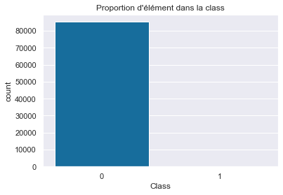

```python
# revérifions la proportion des données dans la Class
sns.countplot(y_test)
plt.title('Proportion d\'élément dans la class')
plt.show()
```

```python
# Réentraînons le modele RF avec nos données Resamplées
rf_resampled = RandomForestClassifier(n_estimators = 100).fit(X_train_sm,y_train_sm)
```

```
======================== -- Resultat de l'évaluation du modèle -- ========================

=====================-- Random forest avec SMOTE --=====================
-----------------------
Score_training: 100.0 %
-----------------------------------------------------------------------------
Le nombre d'erreur est de: 37
-----------------------------------------------------------------------------
Classification report:
               precision    recall  f1-score   support

           0       1.00      1.00      1.00     85305
           1       0.90      0.83      0.86       138

    accuracy                           1.00     85443
   macro avg       0.95      0.91      0.93     85443
weighted avg       1.00      1.00      1.00     85443

-----------------------------------------------------------------------------
Confusion Matrix:
----------------
```

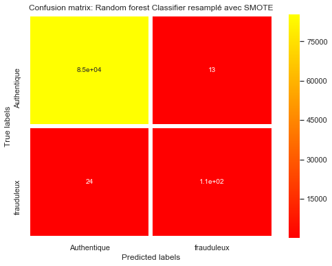

```python
# Réglage
#--------
plt.figure(figsize = (8,6))

# Predisons
#----------
y_pred_rf_resampled = rf_resampled.predict(X_test)

# Performance et metriques
#-------------------------
#score = cross_val_score(RF_Classifier, X_train, y_train, cv = 10)
accuracy = accuracy_score(y_test, y_pred_rf_resampled)
class_report = classification_report(y_test,y_pred_rf_resampled)
cm_rf_resampled_smote = confusion_matrix(y_test,y_pred_rf_resampled)
n_error = (y_pred_rf_resampled != y_test).sum()

# Affichage
#----------
print('======================== -- Resultat de l\'évaluation du modèle -- ========================' "\n")
print('=====================-- Random forest avec SMOTE --=====================')
#print('Score:', round(score.mean(),3) * 100,'%')
print('-----------------------')
print("Score_training:", round(accuracy,3) * 100,'%')
print('-----------------------------------------------------------------------------')
print("Le nombre d'erreur est de: {}".format(n_error))
print('-----------------------------------------------------------------------------')
print("Classification report:"  "\n", class_report)
print('-----------------------------------------------------------------------------')
print("Confusion Matrix:")
print('----------------')
ax= plt.subplot()
sns.heatmap(cm_rf_resampled_smote, cmap = 'autumn', annot = True, linewidths = 5, ax = ax)

# Étiquettes, Titre
ax.set_xlabel('Predicted labels');ax.set_ylabel('True labels');
ax.set_title('Confusion matrix: Random forest Classifier resamplé avec SMOTE');
ax.xaxis.set_ticklabels(['Authentique', 'frauduleux']); ax.yaxis.set_ticklabels(['Authentique', 'frauduleux']);
plt.show()
```

```python
roc_auc_score(y_test , y_pred_rf_resampled)
```

```
0.9129672810860264
```

```python
false_positive_rate_rf_smote, true_positive_rate_rf_smote, thresholds = roc_curve(y_test, y_pred_rf_resampled)
roc_auc = auc(false_positive_rate_rf_smote, true_positive_rate_rf_smote)
print ('ROC AUC:',roc_auc)
```

```
ROC AUC: 0.9129672810860264
```

```
===================== ROC CURVE - Random Forest avec SMOTE ==================
```

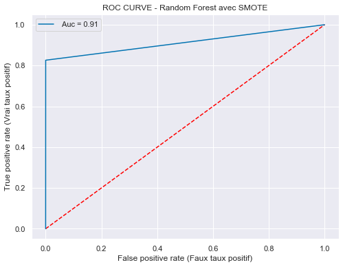

```python
# Roc Curve Random Forest avec SMOTE
print('===================== ROC CURVE - Random Forest avec SMOTE ==================')
plt.figure(figsize = (8,6))
plt.plot([0, 1], [0, 1], 'k--', color ='red')
plt.plot(false_positive_rate_rf_smote, true_positive_rate_rf_smote, label=' Auc = {}'.format(round(roc_auc,2)))
plt.xlabel('False positive rate (Faux taux positif)')
plt.ylabel('True positive rate (Vrai taux positif)')
plt.title('ROC CURVE - Random Forest avec SMOTE')
plt.legend(loc='best')
plt.show()
```